# Risk Factor Analysis

## Outcome Variable

**Outcome Variable:** stunted

## Predictor Variables

**Intervention Variable:** mwtkg

**Adjustment Set:**

unadjusted

## Stratifying Variables

The analysis was stratified on these variable(s):

- agecat
- studyid
- country

## Data Summary

| agecat | studyid | country | mwtkg | stunted | n_cell | n |
| --- | --- | --- | --- | --- | --- | --- |
| Birth | JiVitA-3 | BANGLADESH | >=58 kg | 0 | 374 | 22432 |
| Birth | JiVitA-3 | BANGLADESH | >=58 kg | 1 | 126 | 22432 |
| Birth | JiVitA-3 | BANGLADESH | <52 kg | 0 | 13634 | 22432 |
| Birth | JiVitA-3 | BANGLADESH | <52 kg | 1 | 6845 | 22432 |
| Birth | JiVitA-3 | BANGLADESH | [52-58) kg | 0 | 1046 | 22432 |
| Birth | JiVitA-3 | BANGLADESH | [52-58) kg | 1 | 407 | 22432 |
| Birth | MAL-ED | BANGLADESH | >=58 kg | 0 | 31 | 222 |
| Birth | MAL-ED | BANGLADESH | >=58 kg | 1 | 7 | 222 |
| Birth | MAL-ED | BANGLADESH | <52 kg | 0 | 114 | 222 |
| Birth | MAL-ED | BANGLADESH | <52 kg | 1 | 29 | 222 |
| Birth | MAL-ED | BANGLADESH | [52-58) kg | 0 | 37 | 222 |
| Birth | MAL-ED | BANGLADESH | [52-58) kg | 1 | 4 | 222 |
| Birth | MAL-ED | BRAZIL | >=58 kg | 0 | 31 | 64 |
| Birth | MAL-ED | BRAZIL | >=58 kg | 1 | 3 | 64 |
| Birth | MAL-ED | BRAZIL | <52 kg | 0 | 11 | 64 |
| Birth | MAL-ED | BRAZIL | <52 kg | 1 | 4 | 64 |
| Birth | MAL-ED | BRAZIL | [52-58) kg | 0 | 13 | 64 |
| Birth | MAL-ED | BRAZIL | [52-58) kg | 1 | 2 | 64 |
| Birth | MAL-ED | INDIA | >=58 kg | 0 | 5 | 43 |
| Birth | MAL-ED | INDIA | >=58 kg | 1 | 1 | 43 |
| Birth | MAL-ED | INDIA | <52 kg | 0 | 24 | 43 |
| Birth | MAL-ED | INDIA | <52 kg | 1 | 5 | 43 |
| Birth | MAL-ED | INDIA | [52-58) kg | 0 | 5 | 43 |
| Birth | MAL-ED | INDIA | [52-58) kg | 1 | 3 | 43 |
| Birth | MAL-ED | NEPAL | >=58 kg | 0 | 9 | 27 |
| Birth | MAL-ED | NEPAL | >=58 kg | 1 | 0 | 27 |
| Birth | MAL-ED | NEPAL | <52 kg | 0 | 6 | 27 |
| Birth | MAL-ED | NEPAL | <52 kg | 1 | 2 | 27 |
| Birth | MAL-ED | NEPAL | [52-58) kg | 0 | 10 | 27 |
| Birth | MAL-ED | NEPAL | [52-58) kg | 1 | 0 | 27 |

[output cut: 240 more lines]

The following strata were considered:

- agecat: 24 months, studyid: JiVitA-3, country: BANGLADESH
- agecat: 24 months, studyid: LCNI-5, country: MALAWI
- agecat: 24 months, studyid: MAL-ED, country: BANGLADESH
- agecat: 24 months, studyid: MAL-ED, country: BRAZIL
- agecat: 24 months, studyid: MAL-ED, country: INDIA
- agecat: 24 months, studyid: MAL-ED, country: NEPAL
- agecat: 24 months, studyid: MAL-ED, country: PERU
- agecat: 24 months, studyid: MAL-ED, country: SOUTH AFRICA
- agecat: 24 months, studyid: MAL-ED, country: TANZANIA, UNITED REPUBLIC OF
- agecat: 24 months, studyid: NIH-Birth, country: BANGLADESH
- agecat: 24 months, studyid: NIH-Crypto, country: BANGLADESH
- agecat: 24 months, studyid: PROBIT, country: BELARUS
- agecat: 24 months, studyid: PROVIDE, country: BANGLADESH
- agecat: 24 months, studyid: TanzaniaChild2, country: TANZANIA, UNITED REPUBLIC OF
- agecat: 24 months, studyid: ZVITAMBO, country: ZIMBABWE
- agecat: 6 months, studyid: JiVitA-3, country: BANGLADESH
- agecat: 6 months, studyid: LCNI-5, country: MALAWI
- agecat: 6 months, studyid: MAL-ED, country: BANGLADESH
- agecat: 6 months, studyid: MAL-ED, country: BRAZIL
- agecat: 6 months, studyid: MAL-ED, country: INDIA
- agecat: 6 months, studyid: MAL-ED, country: NEPAL
- agecat: 6 months, studyid: MAL-ED, country: PERU
- agecat: 6 months, studyid: MAL-ED, country: SOUTH AFRICA
- agecat: 6 months, studyid: MAL-ED, country: TANZANIA, UNITED REPUBLIC OF
- agecat: 6 months, studyid: NIH-Birth, country: BANGLADESH
- agecat: 6 months, studyid: NIH-Crypto, country: BANGLADESH
- agecat: 6 months, studyid: PROBIT, country: BELARUS
- agecat: 6 months, studyid: PROVIDE, country: BANGLADESH
- agecat: 6 months, studyid: SAS-CompFeed, country: INDIA
- agecat: 6 months, studyid: TanzaniaChild2, country: TANZANIA, UNITED REPUBLIC OF
- agecat: 6 months, studyid: ZVITAMBO, country: ZIMBABWE
- agecat: Birth, studyid: JiVitA-3, country: BANGLADESH
- agecat: Birth, studyid: MAL-ED, country: BANGLADESH
- agecat: Birth, studyid: MAL-ED, country: BRAZIL
- agecat: Birth, studyid: MAL-ED, country: INDIA
- agecat: Birth, studyid: MAL-ED, country: NEPAL
- agecat: Birth, studyid: MAL-ED, country: PERU
- agecat: Birth, studyid: MAL-ED, country: SOUTH AFRICA
- agecat: Birth, studyid: MAL-ED, country: TANZANIA, UNITED REPUBLIC OF
- agecat: Birth, studyid: NIH-Birth, country: BANGLADESH
- agecat: Birth, studyid: NIH-Crypto, country: BANGLADESH
- agecat: Birth, studyid: PROBIT, country: BELARUS
- agecat: Birth, studyid: PROVIDE, country: BANGLADESH
- agecat: Birth, studyid: SAS-CompFeed, country: INDIA
- agecat: Birth, studyid: ZVITAMBO, country: ZIMBABWE

### Dropped Strata

Some strata were dropped due to rare outcomes:

- agecat: Birth, studyid: MAL-ED, country: BANGLADESH
- agecat: Birth, studyid: MAL-ED, country: BRAZIL
- agecat: Birth, studyid: MAL-ED, country: INDIA
- agecat: Birth, studyid: MAL-ED, country: NEPAL
- agecat: Birth, studyid: MAL-ED, country: SOUTH AFRICA
- agecat: Birth, studyid: MAL-ED, country: TANZANIA, UNITED REPUBLIC OF
- agecat: Birth, studyid: PROBIT, country: BELARUS
- agecat: Birth, studyid: PROVIDE, country: BANGLADESH
- agecat: 6 months, studyid: MAL-ED, country: BANGLADESH
- agecat: 6 months, studyid: MAL-ED, country: BRAZIL
- agecat: 6 months, studyid: MAL-ED, country: INDIA
- agecat: 6 months, studyid: MAL-ED, country: NEPAL
- agecat: 24 months, studyid: MAL-ED, country: BRAZIL
- agecat: 24 months, studyid: TanzaniaChild2, country: TANZANIA, UNITED REPUBLIC OF

## Methods Detail

We’re interested in the causal parameters $E[Y_a]$ for all values of $a \in \mathcal{A}$. These parameters represent the mean outcome if, possibly contrary to fact, we intervened to set all units to have $A=a$. Under the randomization and positivity assumptions, these are identified by the statistical parameters $\psi_a=E_W[E_{Y|A,W}(Y|A=a,W)]$. In addition, we’re interested in the mean of $Y$, $E[Y]$ under no intervention (the observed mean). We will estimate these parameters by using SuperLearner to fit the relevant likelihood factors – $E_{Y|A,W}(Y|A=a,W)$ and $p(A=a|W)$, and then updating our likelihood fit using a joint TMLE.

For unadjusted analyses ($W=\{\}$), initial likelihoods were estimated using Lrnr_glm to estimate the simple $E(Y|A)$ and Lrnr_mean to estimate $p(A)$. For adjusted analyses, a small library containing Lrnr_glmnet, Lrnr_xgboost, and Lrnr_mean was used.

Having estimated these parameters, we will then use the delta method to estimate relative risks and attributable risks relative to a prespecified baseline level of $A$.

# Results Detail

## Results Plots

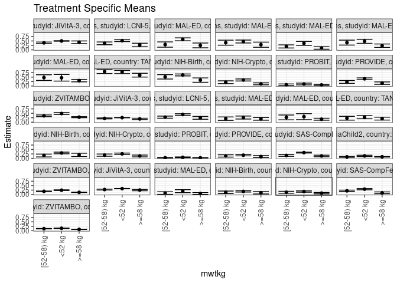

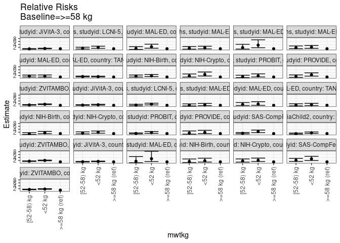

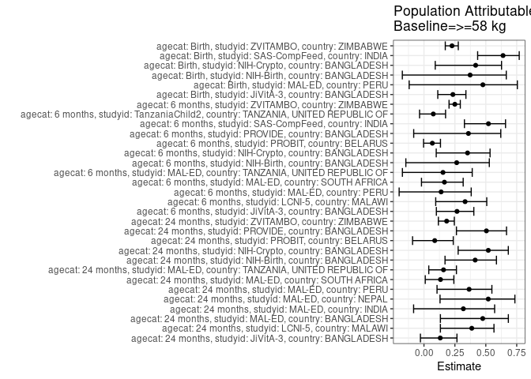

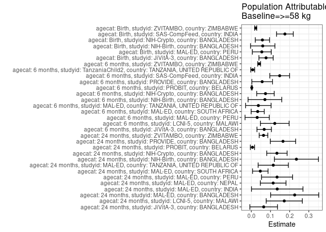

## Results Table

### Parameter: TSM

| agecat | studyid | country | intervention_level | baseline_level | estimate | ci_lower | ci_upper |
| --- | --- | --- | --- | --- | --- | --- | --- |
| Birth | JiVitA-3 | BANGLADESH | >=58 kg | NA | 0.2520000 | 0.2143729 | 0.2896271 |
| Birth | JiVitA-3 | BANGLADESH | <52 kg | NA | 0.3342448 | 0.3266667 | 0.3418230 |
| Birth | JiVitA-3 | BANGLADESH | [52-58) kg | NA | 0.2801101 | 0.2547145 | 0.3055058 |
| Birth | MAL-ED | PERU | >=58 kg | NA | 0.0602410 | 0.0089399 | 0.1115420 |
| Birth | MAL-ED | PERU | <52 kg | NA | 0.1904762 | 0.1063160 | 0.2746364 |
| Birth | MAL-ED | PERU | [52-58) kg | NA | 0.0847458 | 0.0135236 | 0.1559679 |
| Birth | NIH-Birth | BANGLADESH | >=58 kg | NA | 0.1000000 | 0.0342067 | 0.1657933 |
| Birth | NIH-Birth | BANGLADESH | <52 kg | NA | 0.1768707 | 0.1412299 | 0.2125116 |
| Birth | NIH-Birth | BANGLADESH | [52-58) kg | NA | 0.1264368 | 0.0565444 | 0.1963292 |
| Birth | NIH-Crypto | BANGLADESH | >=58 kg | NA | 0.0806452 | 0.0414872 | 0.1198032 |
| Birth | NIH-Crypto | BANGLADESH | <52 kg | NA | 0.1696203 | 0.1325842 | 0.2066563 |
| Birth | NIH-Crypto | BANGLADESH | [52-58) kg | NA | 0.1283784 | 0.0744490 | 0.1823077 |
| Birth | SAS-CompFeed | INDIA | >=58 kg | NA | 0.0989011 | 0.0494314 | 0.1483708 |
| Birth | SAS-CompFeed | INDIA | <52 kg | NA | 0.3045311 | 0.2684154 | 0.3406468 |
| Birth | SAS-CompFeed | INDIA | [52-58) kg | NA | 0.2091837 | 0.1698398 | 0.2485275 |
| Birth | ZVITAMBO | ZIMBABWE | >=58 kg | NA | 0.0781657 | 0.0712314 | 0.0851000 |
| Birth | ZVITAMBO | ZIMBABWE | <52 kg | NA | 0.1386892 | 0.1247591 | 0.1526193 |
| Birth | ZVITAMBO | ZIMBABWE | [52-58) kg | NA | 0.1158474 | 0.1042168 | 0.1274780 |
| 6 months | JiVitA-3 | BANGLADESH | >=58 kg | NA | 0.1842752 | 0.1458420 | 0.2227083 |
| 6 months | JiVitA-3 | BANGLADESH | <52 kg | NA | 0.2560520 | 0.2475676 | 0.2645363 |
| 6 months | JiVitA-3 | BANGLADESH | [52-58) kg | NA | 0.2144097 | 0.1882932 | 0.2405263 |
| 6 months | LCNI-5 | MALAWI | >=58 kg | NA | 0.2456140 | 0.1665501 | 0.3246780 |
| 6 months | LCNI-5 | MALAWI | <52 kg | NA | 0.4325397 | 0.3892611 | 0.4758183 |
| 6 months | LCNI-5 | MALAWI | [52-58) kg | NA | 0.2831050 | 0.2234033 | 0.3428068 |
| 6 months | MAL-ED | PERU | >=58 kg | NA | 0.1900000 | 0.1129687 | 0.2670313 |
| 6 months | MAL-ED | PERU | <52 kg | NA | 0.2616822 | 0.1782441 | 0.3451204 |
| 6 months | MAL-ED | PERU | [52-58) kg | NA | 0.2000000 | 0.1025793 | 0.2974207 |
| 6 months | MAL-ED | SOUTH AFRICA | >=58 kg | NA | 0.1675978 | 0.1127706 | 0.2224250 |
| 6 months | MAL-ED | SOUTH AFRICA | <52 kg | NA | 0.3103448 | 0.1416269 | 0.4790627 |
| 6 months | MAL-ED | SOUTH AFRICA | [52-58) kg | NA | 0.2682927 | 0.1323978 | 0.4041876 |

[output cut: 63 more lines]

### Parameter: E(Y)

| agecat | studyid | country | intervention_level | baseline_level | estimate | ci_lower | ci_upper |
| --- | --- | --- | --- | --- | --- | --- | --- |
| Birth | JiVitA-3 | BANGLADESH | NA | NA | 0.3289051 | 0.3215448 | 0.3362655 |
| Birth | MAL-ED | PERU | NA | NA | 0.1150442 | 0.0733525 | 0.1567360 |
| Birth | NIH-Birth | BANGLADESH | NA | NA | 0.1595395 | 0.1304091 | 0.1886699 |
| Birth | NIH-Crypto | BANGLADESH | NA | NA | 0.1385460 | 0.1134505 | 0.1636414 |
| Birth | SAS-CompFeed | INDIA | NA | NA | 0.2742718 | 0.2403806 | 0.3081631 |
| Birth | ZVITAMBO | ZIMBABWE | NA | NA | 0.1010788 | 0.0954534 | 0.1067041 |
| 6 months | JiVitA-3 | BANGLADESH | NA | NA | 0.2514582 | 0.2433372 | 0.2595791 |
| 6 months | LCNI-5 | MALAWI | NA | NA | 0.3679809 | 0.3352903 | 0.4006715 |
| 6 months | MAL-ED | PERU | NA | NA | 0.2205882 | 0.1712211 | 0.2699554 |
| 6 months | MAL-ED | SOUTH AFRICA | NA | NA | 0.2008032 | 0.1509453 | 0.2506612 |
| 6 months | MAL-ED | TANZANIA, UNITED REPUBLIC OF | NA | NA | 0.2388664 | 0.1855834 | 0.2921494 |
| 6 months | NIH-Birth | BANGLADESH | NA | NA | 0.2681564 | 0.2306532 | 0.3056597 |
| 6 months | NIH-Crypto | BANGLADESH | NA | NA | 0.2097902 | 0.1799252 | 0.2396552 |
| 6 months | PROBIT | BELARUS | NA | NA | 0.0368896 | 0.0278229 | 0.0459564 |
| 6 months | PROVIDE | BANGLADESH | NA | NA | 0.1575456 | 0.1284434 | 0.1866478 |
| 6 months | SAS-CompFeed | INDIA | NA | NA | 0.2839970 | 0.2655949 | 0.3023990 |
| 6 months | TanzaniaChild2 | TANZANIA, UNITED REPUBLIC OF | NA | NA | 0.0965309 | 0.0835493 | 0.1095126 |
| 6 months | ZVITAMBO | ZIMBABWE | NA | NA | 0.1640417 | 0.1560523 | 0.1720310 |
| 24 months | JiVitA-3 | BANGLADESH | NA | NA | 0.4910166 | 0.4779104 | 0.5041227 |
| 24 months | LCNI-5 | MALAWI | NA | NA | 0.4446367 | 0.4040904 | 0.4851830 |
| 24 months | MAL-ED | BANGLADESH | NA | NA | 0.4764151 | 0.4090254 | 0.5438047 |
| 24 months | MAL-ED | INDIA | NA | NA | 0.4247788 | 0.3601902 | 0.4893673 |
| 24 months | MAL-ED | NEPAL | NA | NA | 0.2192982 | 0.1654718 | 0.2731246 |
| 24 months | MAL-ED | PERU | NA | NA | 0.3681592 | 0.3013164 | 0.4350020 |
| 24 months | MAL-ED | SOUTH AFRICA | NA | NA | 0.3504274 | 0.2891665 | 0.4116882 |
| 24 months | MAL-ED | TANZANIA, UNITED REPUBLIC OF | NA | NA | 0.7242991 | 0.6642873 | 0.7843108 |
| 24 months | NIH-Birth | BANGLADESH | NA | NA | 0.5687646 | 0.5218455 | 0.6156837 |
| 24 months | NIH-Crypto | BANGLADESH | NA | NA | 0.2568093 | 0.2190047 | 0.2946140 |
| 24 months | PROBIT | BELARUS | NA | NA | 0.0680289 | 0.0409200 | 0.0951378 |
| 24 months | PROVIDE | BANGLADESH | NA | NA | 0.3275563 | 0.2892291 | 0.3658836 |
| 24 months | ZVITAMBO | ZIMBABWE | NA | NA | 0.3469773 | 0.3235580 | 0.3703967 |

### Parameter: RR

| agecat | studyid | country | intervention_level | baseline_level | estimate | ci_lower | ci_upper |
| --- | --- | --- | --- | --- | --- | --- | --- |
| Birth | JiVitA-3 | BANGLADESH | >=58 kg | >=58 kg | 1.0000000 | 1.0000000 | 1.000000 |
| Birth | JiVitA-3 | BANGLADESH | <52 kg | >=58 kg | 1.3263684 | 1.1402828 | 1.542822 |
| Birth | JiVitA-3 | BANGLADESH | [52-58) kg | >=58 kg | 1.1115481 | 0.9389641 | 1.315853 |
| Birth | MAL-ED | PERU | >=58 kg | >=58 kg | 1.0000000 | 1.0000000 | 1.000000 |
| Birth | MAL-ED | PERU | <52 kg | >=58 kg | 3.1619048 | 1.2114019 | 8.252952 |
| Birth | MAL-ED | PERU | [52-58) kg | >=58 kg | 1.4067797 | 0.4252149 | 4.654186 |
| Birth | NIH-Birth | BANGLADESH | >=58 kg | >=58 kg | 1.0000000 | 1.0000000 | 1.000000 |
| Birth | NIH-Birth | BANGLADESH | <52 kg | >=58 kg | 1.7687075 | 0.8888286 | 3.519606 |
| Birth | NIH-Birth | BANGLADESH | [52-58) kg | >=58 kg | 1.2643678 | 0.5353913 | 2.985902 |
| Birth | NIH-Crypto | BANGLADESH | >=58 kg | >=58 kg | 1.0000000 | 1.0000000 | 1.000000 |
| Birth | NIH-Crypto | BANGLADESH | <52 kg | >=58 kg | 2.1032911 | 1.2350477 | 3.581913 |
| Birth | NIH-Crypto | BANGLADESH | [52-58) kg | >=58 kg | 1.5918919 | 0.8376685 | 3.025206 |
| Birth | SAS-CompFeed | INDIA | >=58 kg | >=58 kg | 1.0000000 | 1.0000000 | 1.000000 |
| Birth | SAS-CompFeed | INDIA | <52 kg | >=58 kg | 3.0791476 | 1.9560693 | 4.847042 |
| Birth | SAS-CompFeed | INDIA | [52-58) kg | >=58 kg | 2.1150794 | 1.3057415 | 3.426069 |
| Birth | ZVITAMBO | ZIMBABWE | >=58 kg | >=58 kg | 1.0000000 | 1.0000000 | 1.000000 |
| Birth | ZVITAMBO | ZIMBABWE | <52 kg | >=58 kg | 1.7742974 | 1.5517689 | 2.028737 |
| Birth | ZVITAMBO | ZIMBABWE | [52-58) kg | >=58 kg | 1.4820740 | 1.2962392 | 1.694551 |
| 6 months | JiVitA-3 | BANGLADESH | >=58 kg | >=58 kg | 1.0000000 | 1.0000000 | 1.000000 |
| 6 months | JiVitA-3 | BANGLADESH | <52 kg | >=58 kg | 1.3895086 | 1.1272159 | 1.712835 |
| 6 months | JiVitA-3 | BANGLADESH | [52-58) kg | >=58 kg | 1.1635301 | 0.9160340 | 1.477895 |
| 6 months | LCNI-5 | MALAWI | >=58 kg | >=58 kg | 1.0000000 | 1.0000000 | 1.000000 |
| 6 months | LCNI-5 | MALAWI | <52 kg | >=58 kg | 1.7610544 | 1.2571127 | 2.467013 |
| 6 months | LCNI-5 | MALAWI | [52-58) kg | >=58 kg | 1.1526419 | 0.7844504 | 1.693649 |
| 6 months | MAL-ED | PERU | >=58 kg | >=58 kg | 1.0000000 | 1.0000000 | 1.000000 |
| 6 months | MAL-ED | PERU | <52 kg | >=58 kg | 1.3772750 | 0.8222730 | 2.306881 |
| 6 months | MAL-ED | PERU | [52-58) kg | >=58 kg | 1.0526316 | 0.5585235 | 1.983862 |
| 6 months | MAL-ED | SOUTH AFRICA | >=58 kg | >=58 kg | 1.0000000 | 1.0000000 | 1.000000 |
| 6 months | MAL-ED | SOUTH AFRICA | <52 kg | >=58 kg | 1.8517241 | 0.9818013 | 3.492440 |
| 6 months | MAL-ED | SOUTH AFRICA | [52-58) kg | >=58 kg | 1.6008130 | 0.8759360 | 2.925559 |

[output cut: 63 more lines]

### Parameter: PAR

| agecat | studyid | country | intervention_level | baseline_level | estimate | ci_lower | ci_upper |
| --- | --- | --- | --- | --- | --- | --- | --- |
| Birth | JiVitA-3 | BANGLADESH | >=58 kg | NA | 0.0769051 | 0.0395836 | 0.1142266 |
| Birth | MAL-ED | PERU | >=58 kg | NA | 0.0548033 | 0.0054382 | 0.1041683 |
| Birth | NIH-Birth | BANGLADESH | >=58 kg | NA | 0.0595395 | -0.0040073 | 0.1230863 |
| Birth | NIH-Crypto | BANGLADESH | >=58 kg | NA | 0.0579008 | 0.0207433 | 0.0950583 |
| Birth | SAS-CompFeed | INDIA | >=58 kg | NA | 0.1753707 | 0.1316984 | 0.2190431 |
| Birth | ZVITAMBO | ZIMBABWE | >=58 kg | NA | 0.0229131 | 0.0174781 | 0.0283481 |
| 6 months | JiVitA-3 | BANGLADESH | >=58 kg | NA | 0.0671830 | 0.0293634 | 0.1050025 |
| 6 months | LCNI-5 | MALAWI | >=58 kg | NA | 0.1223668 | 0.0474204 | 0.1973133 |
| 6 months | MAL-ED | PERU | >=58 kg | NA | 0.0305882 | -0.0327192 | 0.0938957 |
| 6 months | MAL-ED | SOUTH AFRICA | >=58 kg | NA | 0.0332054 | -0.0009987 | 0.0674096 |
| 6 months | MAL-ED | TANZANIA, UNITED REPUBLIC OF | >=58 kg | NA | 0.0367387 | -0.0297425 | 0.1032200 |
| 6 months | NIH-Birth | BANGLADESH | >=58 kg | NA | 0.0709733 | -0.0168808 | 0.1588274 |
| 6 months | NIH-Crypto | BANGLADESH | >=58 kg | NA | 0.0739206 | 0.0282786 | 0.1195626 |
| 6 months | PROBIT | BELARUS | >=58 kg | NA | 0.0024954 | 0.0000174 | 0.0049734 |
| 6 months | PROVIDE | BANGLADESH | >=58 kg | NA | 0.0566282 | 0.0028511 | 0.1104052 |
| 6 months | SAS-CompFeed | INDIA | >=58 kg | NA | 0.1480747 | 0.0965117 | 0.1996376 |
| 6 months | TanzaniaChild2 | TANZANIA, UNITED REPUBLIC OF | >=58 kg | NA | 0.0072879 | -0.0028769 | 0.0174527 |
| 6 months | ZVITAMBO | ZIMBABWE | >=58 kg | NA | 0.0409612 | 0.0333196 | 0.0486029 |
| 24 months | JiVitA-3 | BANGLADESH | >=58 kg | NA | 0.0646206 | -0.0075341 | 0.1367754 |
| 24 months | LCNI-5 | MALAWI | >=58 kg | NA | 0.1719094 | 0.0774877 | 0.2663311 |
| 24 months | MAL-ED | BANGLADESH | >=58 kg | NA | 0.2264151 | 0.1006920 | 0.3521382 |
| 24 months | MAL-ED | INDIA | >=58 kg | NA | 0.1353051 | 0.0010173 | 0.2695928 |
| 24 months | MAL-ED | NEPAL | >=58 kg | NA | 0.1140351 | 0.0470193 | 0.1810508 |
| 24 months | MAL-ED | PERU | >=58 kg | NA | 0.1343930 | 0.0533501 | 0.2154358 |
| 24 months | MAL-ED | SOUTH AFRICA | >=58 kg | NA | 0.0468559 | 0.0064006 | 0.0873112 |
| 24 months | MAL-ED | TANZANIA, UNITED REPUBLIC OF | >=58 kg | NA | 0.1145430 | 0.0356875 | 0.1933984 |
| 24 months | NIH-Birth | BANGLADESH | >=58 kg | NA | 0.2354312 | 0.1204365 | 0.3504260 |
| 24 months | NIH-Crypto | BANGLADESH | >=58 kg | NA | 0.1336209 | 0.0804785 | 0.1867634 |
| 24 months | PROBIT | BELARUS | >=58 kg | NA | 0.0059233 | -0.0049538 | 0.0168004 |
| 24 months | PROVIDE | BANGLADESH | >=58 kg | NA | 0.1653942 | 0.0993115 | 0.2314768 |
| 24 months | ZVITAMBO | ZIMBABWE | >=58 kg | NA | 0.0636640 | 0.0412488 | 0.0860792 |

### Parameter: PAF

| agecat | studyid | country | intervention_level | baseline_level | estimate | ci_lower | ci_upper |
| --- | --- | --- | --- | --- | --- | --- | --- |
| Birth | JiVitA-3 | BANGLADESH | >=58 kg | NA | 0.2338216 | 0.1117220 | 0.3391378 |
| Birth | MAL-ED | PERU | >=58 kg | NA | 0.4763670 | -0.1196867 | 0.7551176 |
| Birth | NIH-Birth | BANGLADESH | >=58 kg | NA | 0.3731959 | -0.1749439 | 0.6656152 |
| Birth | NIH-Crypto | BANGLADESH | >=58 kg | NA | 0.4179176 | 0.0911331 | 0.6272062 |
| Birth | SAS-CompFeed | INDIA | >=58 kg | NA | 0.6394048 | 0.4340269 | 0.7702561 |
| Birth | ZVITAMBO | ZIMBABWE | >=58 kg | NA | 0.2266852 | 0.1723265 | 0.2774738 |
| 6 months | JiVitA-3 | BANGLADESH | >=58 kg | NA | 0.2671736 | 0.1002531 | 0.4031270 |
| 6 months | LCNI-5 | MALAWI | >=58 kg | NA | 0.3325359 | 0.0950235 | 0.5077128 |
| 6 months | MAL-ED | PERU | >=58 kg | NA | 0.1386667 | -0.2007227 | 0.3821262 |
| 6 months | MAL-ED | SOUTH AFRICA | >=58 kg | NA | 0.1653631 | -0.0200531 | 0.3170760 |
| 6 months | MAL-ED | TANZANIA, UNITED REPUBLIC OF | >=58 kg | NA | 0.1538045 | -0.1743662 | 0.3902696 |
| 6 months | NIH-Birth | BANGLADESH | >=58 kg | NA | 0.2646714 | -0.1465927 | 0.5284217 |
| 6 months | NIH-Crypto | BANGLADESH | >=58 kg | NA | 0.3523551 | 0.0991330 | 0.5343997 |
| 6 months | PROBIT | BELARUS | >=58 kg | NA | 0.0676447 | -0.0031438 | 0.1334378 |
| 6 months | PROVIDE | BANGLADESH | >=58 kg | NA | 0.3594399 | -0.0830134 | 0.6211337 |
| 6 months | SAS-CompFeed | INDIA | >=58 kg | NA | 0.5213952 | 0.3271801 | 0.6595484 |
| 6 months | TanzaniaChild2 | TANZANIA, UNITED REPUBLIC OF | >=58 kg | NA | 0.0754980 | -0.0355930 | 0.1746720 |
| 6 months | ZVITAMBO | ZIMBABWE | >=58 kg | NA | 0.2497001 | 0.2028455 | 0.2938008 |
| 24 months | JiVitA-3 | BANGLADESH | >=58 kg | NA | 0.1316058 | -0.0285765 | 0.2668426 |
| 24 months | LCNI-5 | MALAWI | >=58 kg | NA | 0.3866289 | 0.1329489 | 0.5660878 |
| 24 months | MAL-ED | BANGLADESH | >=58 kg | NA | 0.4752475 | 0.1329613 | 0.6824073 |
| 24 months | MAL-ED | INDIA | >=58 kg | NA | 0.3185307 | -0.0837576 | 0.5714905 |
| 24 months | MAL-ED | NEPAL | >=58 kg | NA | 0.5200000 | 0.1299938 | 0.7351743 |
| 24 months | MAL-ED | PERU | >=58 kg | NA | 0.3650404 | 0.1056168 | 0.5492159 |
| 24 months | MAL-ED | SOUTH AFRICA | >=58 kg | NA | 0.1337108 | 0.0103960 | 0.2416593 |
| 24 months | MAL-ED | TANZANIA, UNITED REPUBLIC OF | >=58 kg | NA | 0.1581432 | 0.0388790 | 0.2626081 |
| 24 months | NIH-Birth | BANGLADESH | >=58 kg | NA | 0.4139344 | 0.1702772 | 0.5860390 |
| 24 months | NIH-Crypto | BANGLADESH | >=58 kg | NA | 0.5203118 | 0.2763564 | 0.6820248 |
| 24 months | PROBIT | BELARUS | >=58 kg | NA | 0.0870702 | -0.0921559 | 0.2368848 |
| 24 months | PROVIDE | BANGLADESH | >=58 kg | NA | 0.5049335 | 0.2626577 | 0.6676024 |
| 24 months | ZVITAMBO | ZIMBABWE | >=58 kg | NA | 0.1834817 | 0.1164261 | 0.2454484 |